# Supervised Learning Classification Project: AllLife Bank Personal Loan Campaign

## Problem Statement

### Context

AllLife Bank is a US bank that has a growing customer base. The majority of these customers are liability customers (depositors) with varying sizes of deposits. The number of customers who are also borrowers (asset customers) is quite small, and the bank is interested in expanding this base rapidly to bring in more loan business and in the process, earn more through the interest on loans. In particular, the management wants to explore ways of converting its liability customers to personal loan customers (while retaining them as depositors).

A campaign that the bank ran last year for liability customers showed a healthy conversion rate of over 9% success. This has encouraged the retail marketing department to devise campaigns with better target marketing to increase the success ratio.

You as a Data scientist at AllLife bank have to build a model that will help the marketing department to identify the potential customers who have a higher probability of purchasing the loan.

### Objective

To predict whether a liability customer will buy personal loans, to understand which customer attributes are most significant in driving purchases, and identify which segment of customers to target more.

### Data Dictionary

- `ID`: Customer ID
- `Age`: Customer’s age in completed years
- `Experience`: #years of professional experience
- `Income`: Annual income of the customer (in thousand dollars)
- `ZIP Code`: Home Address ZIP code.
- `Family`: the Family size of the customer
- `CCAvg`: Average spending on credit cards per month (in thousand dollars)
- `Education`: Education Level. 1: Undergrad; 2: Graduate;3: Advanced/Professional
- `Mortgage`: Value of house mortgage if any. (in thousand dollars)
- `Personal_Loan`: Did this customer accept the personal loan offered in the last campaign? (0: No, 1: Yes)
- `Securities_Account`: Does the customer have securities account with the bank? (0: No, 1: Yes)
- `CD_Account`: Does the customer have a certificate of deposit (CD) account with the bank? (0: No, 1: Yes)
- `Online`: Do customers use internet banking facilities? (0: No, 1: Yes)
- `CreditCard`: Does the customer use a credit card issued by any other Bank (excluding All life Bank)? (0: No, 1: Yes)

## Importing necessary libraries

```python
#Importing necessary libraries

import pandas as pd
import numpy as np

# Library to split training and test data
from sklearn.model_selection import train_test_split

# libaries to help with EDA
import matplotlib.pyplot as plt
import seaborn as sns

# To build model for prediction
from sklearn.linear_model import LogisticRegression
from sklearn.tree import DecisionTreeClassifier
from sklearn import tree

# To tune different models
from sklearn.model_selection import GridSearchCV

from sklearn.metrics import (
    f1_score,
    accuracy_score,
    recall_score,
    precision_score,
    confusion_matrix,
    roc_auc_score,
    #plot_confusion_matrix,
    precision_recall_curve,
    roc_curve,
    make_scorer,
)
```

## Loading the dataset

```python
Loan = pd.read_csv("Loan_Modelling.csv");

Loan.head()
```

|  | ID | Age | Experience | Income | ZIPCode | Family | CCAvg | Education | Mortgage | Personal_Loan | Securities_Account | CD_Account | Online | CreditCard |
| --- | --- | --- | --- | --- | --- | --- | --- | --- | --- | --- | --- | --- | --- | --- |
| 0 | 1 | 25 | 1 | 49 | 91107 | 4 | 1.6 | 1 | 0 | 0 | 1 | 0 | 0 | 0 |
| 1 | 2 | 45 | 19 | 34 | 90089 | 3 | 1.5 | 1 | 0 | 0 | 1 | 0 | 0 | 0 |
| 2 | 3 | 39 | 15 | 11 | 94720 | 1 | 1.0 | 1 | 0 | 0 | 0 | 0 | 0 | 0 |
| 3 | 4 | 35 | 9 | 100 | 94112 | 1 | 2.7 | 2 | 0 | 0 | 0 | 0 | 0 | 0 |
| 4 | 5 | 35 | 8 | 45 | 91330 | 4 | 1.0 | 2 | 0 | 0 | 0 | 0 | 0 | 1 |

```python
## Creating a copy of the data

loan_copy_1 = Loan.copy()
```

## Data Overview

- Observations
- Sanity checks

```python
loan_copy_1.shape
```

```
(5000, 14)
```

```python
loan_copy_1.info()
```

```
<class 'pandas.core.frame.DataFrame'>
RangeIndex: 5000 entries, 0 to 4999
Data columns (total 14 columns):
 #   Column              Non-Null Count  Dtype
---  ------              --------------  -----
 0   ID                  5000 non-null   int64
 1   Age                 5000 non-null   int64
 2   Experience          5000 non-null   int64
 3   Income              5000 non-null   int64
 4   ZIPCode             5000 non-null   int64
 5   Family              5000 non-null   int64
 6   CCAvg               5000 non-null   float64
 7   Education           5000 non-null   int64
 8   Mortgage            5000 non-null   int64
 9   Personal_Loan       5000 non-null   int64
 10  Securities_Account  5000 non-null   int64
 11  CD_Account          5000 non-null   int64
 12  Online              5000 non-null   int64
 13  CreditCard          5000 non-null   int64
dtypes: float64(1), int64(13)
memory usage: 547.0 KB
```

```python
loan_copy_1.isnull().sum()
```

```
ID                    0
Age                   0
Experience            0
Income                0
ZIPCode               0
Family                0
CCAvg                 0
Education             0
Mortgage              0
Personal_Loan         0
Securities_Account    0
CD_Account            0
Online                0
CreditCard            0
dtype: int64
```

```python
loan_copy_1.describe().T
```

|  | count | mean | std | min | 25% | 50% | 75% | max |
| --- | --- | --- | --- | --- | --- | --- | --- | --- |
| ID | 5000.0 | 2500.500000 | 1443.520003 | 1.0 | 1250.75 | 2500.5 | 3750.25 | 5000.0 |
| Age | 5000.0 | 45.338400 | 11.463166 | 23.0 | 35.00 | 45.0 | 55.00 | 67.0 |
| Experience | 5000.0 | 20.104600 | 11.467954 | -3.0 | 10.00 | 20.0 | 30.00 | 43.0 |
| Income | 5000.0 | 73.774200 | 46.033729 | 8.0 | 39.00 | 64.0 | 98.00 | 224.0 |
| ZIPCode | 5000.0 | 93169.257000 | 1759.455086 | 90005.0 | 91911.00 | 93437.0 | 94608.00 | 96651.0 |
| Family | 5000.0 | 2.396400 | 1.147663 | 1.0 | 1.00 | 2.0 | 3.00 | 4.0 |
| CCAvg | 5000.0 | 1.937938 | 1.747659 | 0.0 | 0.70 | 1.5 | 2.50 | 10.0 |
| Education | 5000.0 | 1.881000 | 0.839869 | 1.0 | 1.00 | 2.0 | 3.00 | 3.0 |
| Mortgage | 5000.0 | 56.498800 | 101.713802 | 0.0 | 0.00 | 0.0 | 101.00 | 635.0 |
| Personal_Loan | 5000.0 | 0.096000 | 0.294621 | 0.0 | 0.00 | 0.0 | 0.00 | 1.0 |
| Securities_Account | 5000.0 | 0.104400 | 0.305809 | 0.0 | 0.00 | 0.0 | 0.00 | 1.0 |
| CD_Account | 5000.0 | 0.060400 | 0.238250 | 0.0 | 0.00 | 0.0 | 0.00 | 1.0 |
| Online | 5000.0 | 0.596800 | 0.490589 | 0.0 | 0.00 | 1.0 | 1.00 | 1.0 |
| CreditCard | 5000.0 | 0.294000 | 0.455637 | 0.0 | 0.00 | 0.0 | 1.00 | 1.0 |

```python
# Count of people with various education levels:

loan_copy_1['Education'].value_counts()
```

```
1    2096
3    1501
2    1403
Name: Education, dtype: int64
```

```python
# Count of people that accepted a personal loan.

loan_copy_1['Personal_Loan'].value_counts()
```

```
0    4520
1     480
Name: Personal_Loan, dtype: int64
```

```python
# Count of people that have a securities account.

loan_copy_1['Securities_Account'].value_counts()
```

```
0    4478
1     522
Name: Securities_Account, dtype: int64
```

```python
# Count of people that have a CD_Account account.

loan_copy_1['CD_Account'].value_counts()
```

```
0    4698
1     302
Name: CD_Account, dtype: int64
```

```python
# Count of people that have a CD_Account account.

loan_copy_1['Online'].value_counts()
```

```
1    2984
0    2016
Name: Online, dtype: int64
```

```python
# Count of people that have a CreditCard account with another back

loan_copy_1['CreditCard'].value_counts()
```

```
0    3530
1    1470
Name: CreditCard, dtype: int64
```

#### Observations about the data (overview):

1. There are 5000 rows and a total of 14 columns
2. Non are no null data in any of the rows.
3. All the rows have non-null data and are int type except CCAvg which is of type float.
4. Income: The mean annual income of the customer is 73.77 thousand dollars
5. Age: The average age of a cutomer is 45 years and the min being 23 and the max being 67.
6. Experience: Average experience shows up as 20 years, and the max as 43 years. </br> *This min years of experience shows as -3 and needs to be validated for outlier detection or any anomaly in the data and may need correction*
7. Family Size: The min number of people in a family is 1 and the max is 4
8. Credit Card usage: the average cc usage us 1.93K and the min being 0 and max being 10K
9. Education Level: Customers with undergrad, grad and professional education are:</br> Undergrad: 2096 </br> Graduate: 1403 </br> Professional/Advanced: 1501 </br>
10. Mortgage: The avg mortgage that a customer has is 56.5K. The minimum being 0 and the maximum being 635K.
11. Personal Loan: There are 480 people with a personal loan and 4520 (remaning) that have not taken a personal loan.
12. Securities_Account: There are 522 customers with a security account.
13. CD_Account: There are 302 customers with a CD Account.
14. Online Banking: There are 2984 customers that use online banking.
15. CreditCard (Other banks): There are 1470 customers that have a CC with another bank.

## Data Preprocessing

Data must be pre-processed before the EDA so that we remove any nulls, consider the outliers etc.

- Missing value treatment
- Feature engineering (if needed)
- Outlier detection and treatment (if needed)
- Preparing data for modeling
- Any other preprocessing steps (if needed)

###### Experience review

We saw in the data overview that some of the rows had experience < 0. We will now review these outliers and cleanup if required.

```python
loan_copy_1[loan_copy_1["Experience"] < 0]["Experience"].unique()
```

```
array([-1, -2, -3])
```

```python
loan_copy_1[loan_copy_1["Experience"] < 0].head()
```

|  | ID | Age | Experience | Income | ZIPCode | Family | CCAvg | Education | Mortgage | Personal_Loan | Securities_Account | CD_Account | Online | CreditCard |
| --- | --- | --- | --- | --- | --- | --- | --- | --- | --- | --- | --- | --- | --- | --- |
| 89 | 90 | 25 | -1 | 113 | 94303 | 4 | 2.30 | 3 | 0 | 0 | 0 | 0 | 0 | 1 |
| 226 | 227 | 24 | -1 | 39 | 94085 | 2 | 1.70 | 2 | 0 | 0 | 0 | 0 | 0 | 0 |
| 315 | 316 | 24 | -2 | 51 | 90630 | 3 | 0.30 | 3 | 0 | 0 | 0 | 0 | 1 | 0 |
| 451 | 452 | 28 | -2 | 48 | 94132 | 2 | 1.75 | 3 | 89 | 0 | 0 | 0 | 1 | 0 |
| 524 | 525 | 24 | -1 | 75 | 93014 | 4 | 0.20 | 1 | 0 | 0 | 0 | 0 | 1 | 0 |

```python
loan_copy_1[loan_copy_1["Experience"] < 0].tail()
```

|  | ID | Age | Experience | Income | ZIPCode | Family | CCAvg | Education | Mortgage | Personal_Loan | Securities_Account | CD_Account | Online | CreditCard |
| --- | --- | --- | --- | --- | --- | --- | --- | --- | --- | --- | --- | --- | --- | --- |
| 4411 | 4412 | 23 | -2 | 75 | 90291 | 2 | 1.80 | 2 | 0 | 0 | 0 | 0 | 1 | 1 |
| 4481 | 4482 | 25 | -2 | 35 | 95045 | 4 | 1.00 | 3 | 0 | 0 | 0 | 0 | 1 | 0 |
| 4514 | 4515 | 24 | -3 | 41 | 91768 | 4 | 1.00 | 3 | 0 | 0 | 0 | 0 | 1 | 0 |
| 4582 | 4583 | 25 | -1 | 69 | 92691 | 3 | 0.30 | 3 | 0 | 0 | 0 | 0 | 1 | 0 |
| 4957 | 4958 | 29 | -1 | 50 | 95842 | 2 | 1.75 | 3 | 0 | 0 | 0 | 0 | 0 | 1 |

#### Observation:

##### This looks like a data being incorrectly ingested. We can infer from this that these are customers from the age group 25-30 years of age and should have atleaset 1-3 years in experience. This needs to be corrected in the dataset.

```python
# Correcting the experience values
loan_copy_1["Experience"].replace(-1, 1, inplace=True)
loan_copy_1["Experience"].replace(-2, 2, inplace=True)
loan_copy_1["Experience"].replace(-3, 3, inplace=True)
```

```python
# Converting the below columns to categorical columns, identifying the values of these columns with a fixed number of
# values

cat_cols_1 = [
    "Education",
    "Personal_Loan",
    "Securities_Account",
    "CD_Account",
    "Online",
    "CreditCard",
    "ZIPCode",
]
loan_copy_1[cat_cols_1] = loan_copy_1[cat_cols_1].astype("category")
```

```python
loan_copy_1.head()
```

|  | ID | Age | Experience | Income | ZIPCode | Family | CCAvg | Education | Mortgage | Personal_Loan | Securities_Account | CD_Account | Online | CreditCard |
| --- | --- | --- | --- | --- | --- | --- | --- | --- | --- | --- | --- | --- | --- | --- |
| 0 | 1 | 25 | 1 | 49 | 91107 | 4 | 1.6 | 1 | 0 | 0 | 1 | 0 | 0 | 0 |
| 1 | 2 | 45 | 19 | 34 | 90089 | 3 | 1.5 | 1 | 0 | 0 | 1 | 0 | 0 | 0 |
| 2 | 3 | 39 | 15 | 11 | 94720 | 1 | 1.0 | 1 | 0 | 0 | 0 | 0 | 0 | 0 |
| 3 | 4 | 35 | 9 | 100 | 94112 | 1 | 2.7 | 2 | 0 | 0 | 0 | 0 | 0 | 0 |
| 4 | 5 | 35 | 8 | 45 | 91330 | 4 | 1.0 | 2 | 0 | 0 | 0 | 0 | 0 | 1 |

## Exploratory Data Analysis.

- EDA is an important part of any project involving data.
- It is important to investigate and understand the data better before building a model with it.
- A few questions have been mentioned below which will help you approach the analysis in the right manner and generate insights from the data.
- A thorough analysis of the data, in addition to the questions mentioned below, should be done.

**Questions**:

1. What is the distribution of mortgage attribute? Are there any noticeable patterns or outliers in the distribution?
2. How many customers have credit cards?
3. What are the attributes that have a strong correlation with the target attribute (personal loan)?
4. How does a customer's interest in purchasing a loan vary with their age?
5. How does a customer's interest in purchasing a loan vary with their education?

```python
loan_copy_1.head()
```

|  | ID | Age | Experience | Income | ZIPCode | Family | CCAvg | Education | Mortgage | Personal_Loan | Securities_Account | CD_Account | Online | CreditCard |
| --- | --- | --- | --- | --- | --- | --- | --- | --- | --- | --- | --- | --- | --- | --- |
| 0 | 1 | 25 | 1 | 49 | 91107 | 4 | 1.6 | 1 | 0 | 0 | 1 | 0 | 0 | 0 |
| 1 | 2 | 45 | 19 | 34 | 90089 | 3 | 1.5 | 1 | 0 | 0 | 1 | 0 | 0 | 0 |
| 2 | 3 | 39 | 15 | 11 | 94720 | 1 | 1.0 | 1 | 0 | 0 | 0 | 0 | 0 | 0 |
| 3 | 4 | 35 | 9 | 100 | 94112 | 1 | 2.7 | 2 | 0 | 0 | 0 | 0 | 0 | 0 |
| 4 | 5 | 35 | 8 | 45 | 91330 | 4 | 1.0 | 2 | 0 | 0 | 0 | 0 | 0 | 1 |

#### --------------- Mortgage Analysis ---------------

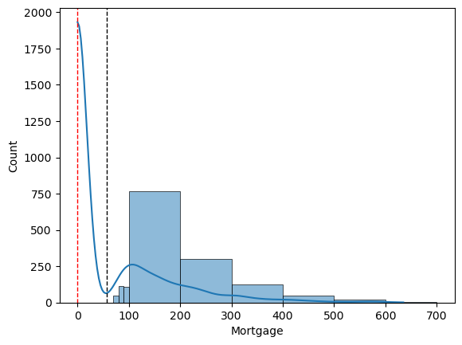

```python
# Verifying the mortgages taken by a customer to see there is anomaly in the data:

sns.histplot(data=loan_copy_1,x='Mortgage', bins=[10, 20, 30, 40, 50, 60, 70, 80, 90, 100, 200, 300, 400, 500, 600, 700], kde=True )
plt.axvline(loan_copy_1['Mortgage'].mean(), color='black', linestyle='dashed', linewidth=1)
plt.axvline(np.median(loan_copy_1['Mortgage']), color='red', linestyle='dashed', linewidth=1)
plt.show()
```

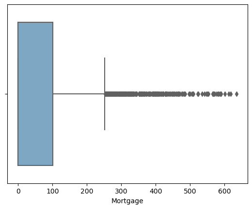

```python
sns.boxplot(data=loan_copy_1,x='Mortgage', palette = 'PuBu')
plt.show()
```

#### --------------- Age Analysis ---------------

1. Most of the customers in the bank fall in the age group between 30 - 60 years
2. There are a good number of customers in between 20-30 years as well. However this is low compared to the 30-60 years age group. Similar trend we see with customers above 60 years too.
3. The median age group is 45 years.

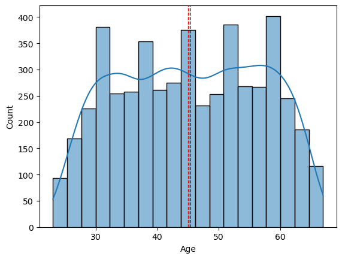

```python
sns.histplot(data=loan_copy_1,x='Age', kde=True )
plt.axvline(loan_copy_1['Age'].mean(), color='black', linestyle='dashed', linewidth=1)
plt.axvline(np.median(loan_copy_1['Age']), color='red', linestyle='dashed', linewidth=1)

plt.show()
```

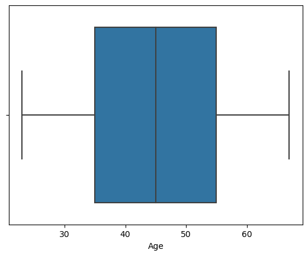

```python
sns.boxplot(data=loan_copy_1,x='Age')
plt.show()
```

#### --------------- Experience Analysis ---------------

1. We see that the customers in the bank have varied experience levels, with people having 0 - 40 years exp.
2. The median experience is 20 years.

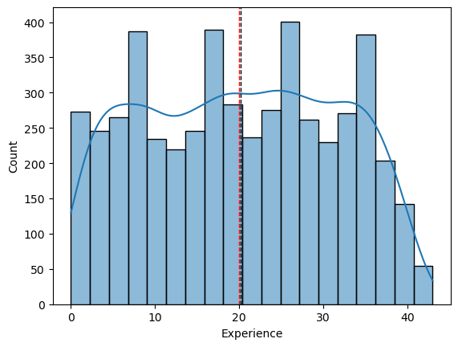

```python
sns.histplot(data=loan_copy_1,x='Experience', kde=True )
plt.axvline(loan_copy_1['Experience'].mean(), color='black', linestyle='dashed', linewidth=1)
plt.axvline(np.median(loan_copy_1['Experience']), color='red', linestyle='dashed', linewidth=1)
plt.show()
```

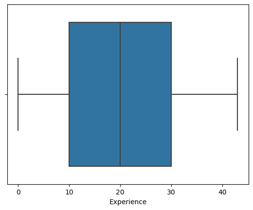

```python
sns.boxplot(data=loan_copy_1,x='Experience' )
plt.show()
```

#### --------------- Income Analysis ---------------

1. The median income is around 70K
2. Some of the customers have income above 200K

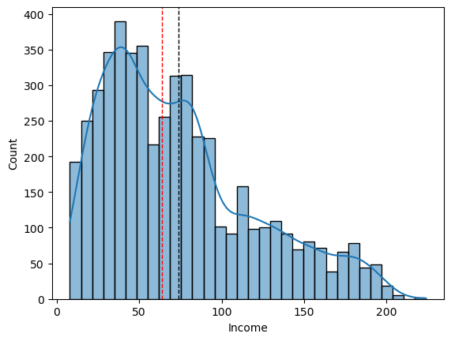

```python
sns.histplot(data=loan_copy_1,x='Income', kde=True )
plt.axvline(loan_copy_1['Income'].mean(), color='black', linestyle='dashed', linewidth=1)
plt.axvline(np.median(loan_copy_1['Income']), color='red', linestyle='dashed', linewidth=1)
plt.show()
```

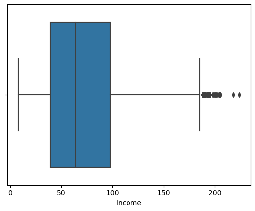

```python
sns.boxplot(data=loan_copy_1,x='Income' )
plt.show()
```

#### --------------- Credit Card Average Analysis ---------------

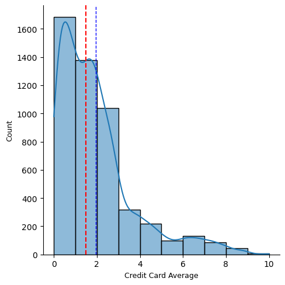

```python
sns.displot(loan_copy_1, x = "CCAvg", bins=10, height=5, kde=True)
plt.xlabel("Credit Card Average", size=9)
plt.ylabel("Count", size=9)
plt.axvline(x=loan_copy_1.CCAvg.median(),color='red',ls='--', lw=1.5)
plt.axvline(loan_copy_1['CCAvg'].mean(), color='blue', linestyle='dashed', linewidth=1)

plt.show()
```

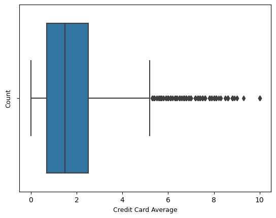

```python
sns.boxplot(data=loan_copy_1,x='CCAvg')
plt.xlabel("Credit Card Average", size=9)
plt.ylabel("Count", size=9)
plt.show()
```

#### --------------- Family Analysis ---------------

1. Median number of people in a family is 2
2. Min is 1 and max is 4

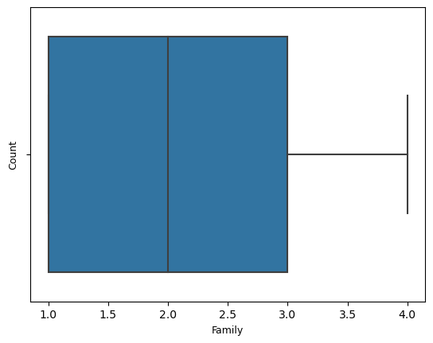

```python
sns.boxplot(data=loan_copy_1,x='Family')
plt.xlabel("Family", size=9)
plt.ylabel("Count", size=9)
plt.show()
```

#### --------------- Education Analysis ---------------

Here, 1 = Undergraduate 2 = Graduate 3 = Professional

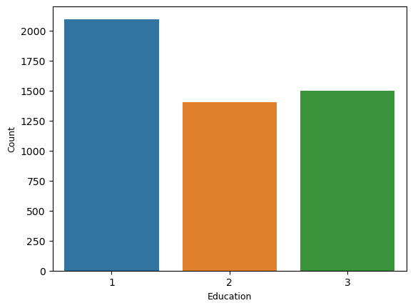

```python
sns.countplot(data = loan_copy_1, x = "Education")
plt.xlabel("Education", size=9)
plt.ylabel("Count", size=9)


plt.show()
```

#### --------------- Securities Account Analysis ---------------

- There are less than 1000 customers with a Securities_Account

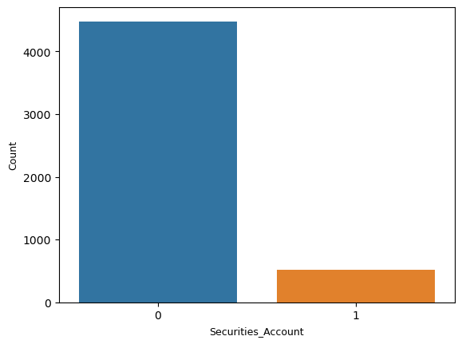

```python
sns.countplot(data = loan_copy_1, x = "Securities_Account")
plt.xlabel("Securities_Account", size=9)
plt.ylabel("Count", size=9)


plt.show()
```

#### --------------- CD_Account Analysis ---------------

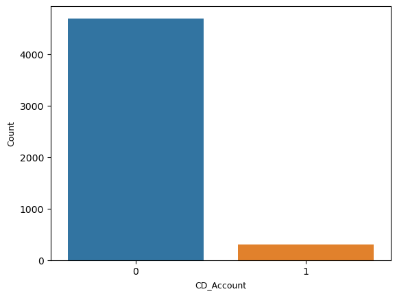

```python
sns.countplot(data = loan_copy_1, x = "CD_Account")
plt.xlabel("CD_Account", size=9)
plt.ylabel("Count", size=9)


plt.show()
```

#### --------------- Online Analysis ---------------

There are close to 3000 customers who do online banking.

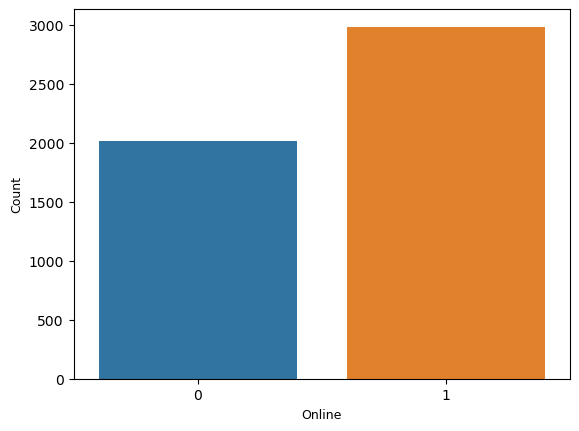

```python
sns.countplot(data = loan_copy_1, x = "Online")
plt.xlabel("Online", size=9)
plt.ylabel("Count", size=9)


plt.show()
```

#### --------------- Credit Card Analysis ---------------

- Around 1500 customers use cc from another bank.

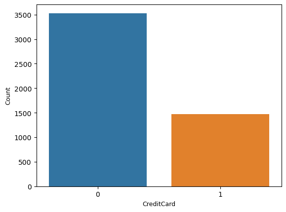

```python
sns.countplot(data = loan_copy_1, x = "CreditCard")
plt.xlabel("CreditCard", size=9)
plt.ylabel("Count", size=9)


plt.show()
```

#### --------------- ZIPCode Analysis ---------------

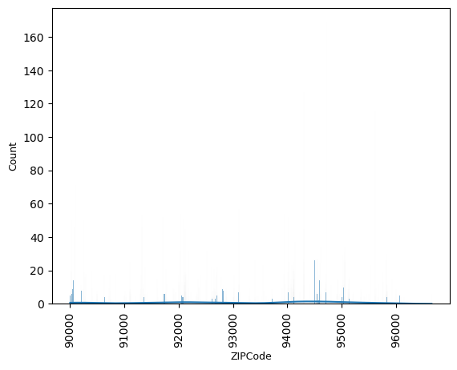

```python
sns.histplot(data=loan_copy_1,x='ZIPCode', kde=True)
plt.xlabel("ZIPCode", size=9)
plt.ylabel("Count", size=9)
#rotate the x-labels so the zipcodes are easier to read
plt.xticks(rotation = 90);

plt.show()
```

1. Income and CC Average usage has a high correlation.
2. Mortgage amount and Income has a direct correlation and shows up as well.
3. Age and years of experience also captures the correct correlation.

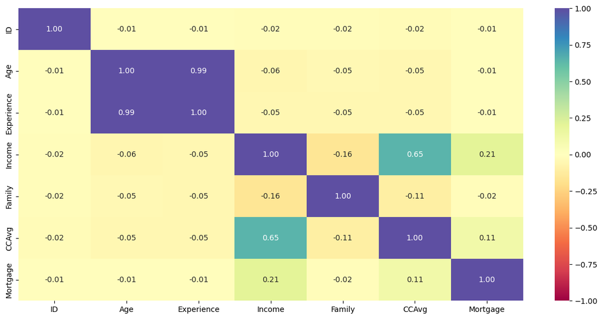

```python
# Plotting the heatmap
plt.figure(figsize=(15, 7))
sns.heatmap(loan_copy_1.corr(), annot=True, vmin=-1, vmax=1, fmt=".2f", cmap="Spectral")
plt.show()
```

#### Scatter-plot between numeric variables

1. Creating a scatter plot between numeric variables : 'Age','Experience','Income','Family','CCAvg', 'Mortgage'
2. We see relationship between Age-Experience, Income-CCAvg, Income-Mortgage

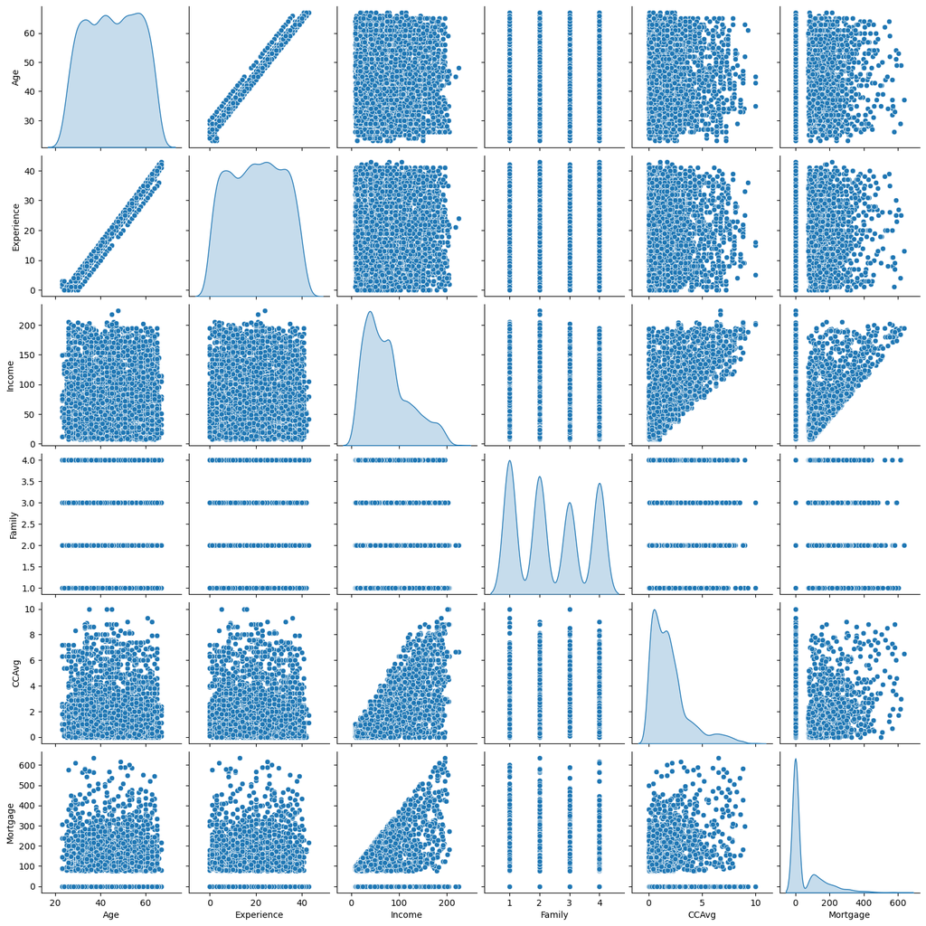

```python
# Numeric variables:
num_variables = ['Age','Experience','Income','Family','CCAvg', 'Mortgage']


sns.pairplot(data=loan_copy_1[num_variables], diag_kind="kde")
plt.show()
```

#### Exploring the relationships between the attributes

#### Income and Credit Card Average

- We can see that there are a folks with higher income have higher credit card usage.

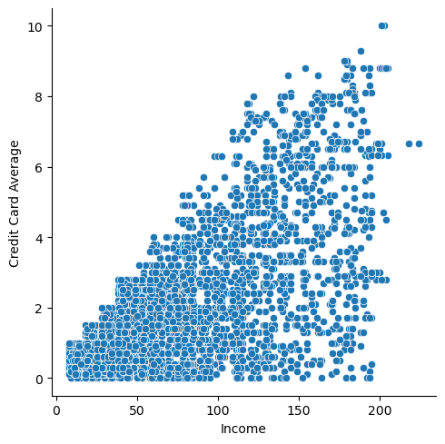

```python
plt.figure(figsize=(55,25))
sns.relplot(data=loan_copy_1, x="Income", y="CCAvg")
plt.ylabel('Credit Card Average')
plt.xlabel('Income')
plt.show()
```

#### Comparision of Categorical features where we compare Personal Loan with other features, beneficial for the bank to identify credit worthy clients.

#### Personal Loan Vs CreditCard

- From the metric we can see that there is not much difference betwen customers who use Credit Card or not on Personal Loans taken.

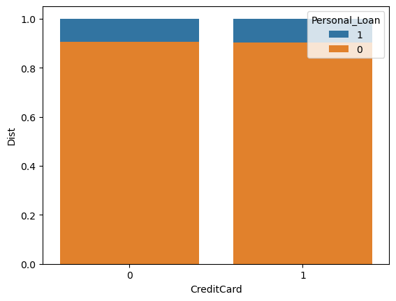

```python
# calculate the distribution of `Personal` per `CreditCard`
distribution = pd.crosstab(loan_copy_1.CreditCard, loan_copy_1.Personal_Loan, normalize='index')

# plot the cumsum, with reverse hue order
sns.barplot(data=distribution.cumsum(axis=1).stack().reset_index(name='Dist'),
            x='CreditCard', y='Dist', hue='Personal_Loan',
            hue_order = distribution.columns[::-1],   # reverse hue order so that the taller bars got plotted first
            dodge=False)
```

#### Personal Loan Vs Family

- From the metric we can see that the families with more members have taken loans.
- This data is beneficial for the bank for targeting the correct audience.

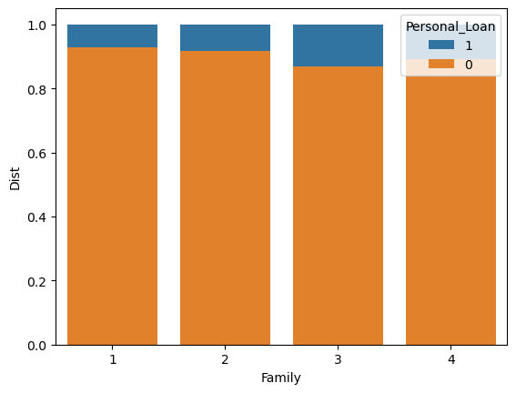

```python
distribution = pd.crosstab(loan_copy_1.Family, loan_copy_1.Personal_Loan, normalize='index')

# plot the cumsum, with reverse hue order
sns.barplot(data=distribution.cumsum(axis=1).stack().reset_index(name='Dist'),
            x='Family', y='Dist', hue='Personal_Loan',
            hue_order = distribution.columns[::-1],   # reverse hue order so that the taller bars got plotted first
            dodge=False)
```

#### Personal Loan Vs Securities_Account

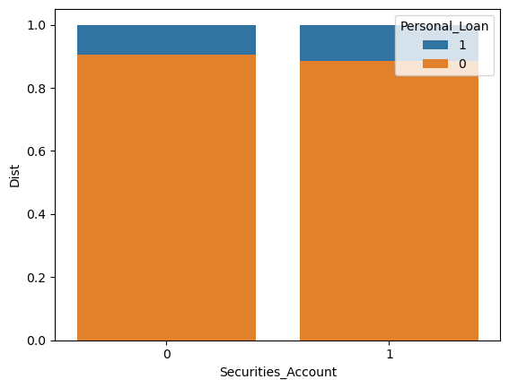

```python
distribution = pd.crosstab(loan_copy_1.Securities_Account, loan_copy_1.Personal_Loan, normalize='index')

# plot the cumsum, with reverse hue order
sns.barplot(data=distribution.cumsum(axis=1).stack().reset_index(name='Dist'),
            x='Securities_Account', y='Dist', hue='Personal_Loan',
            hue_order = distribution.columns[::-1],   # reverse hue order so that the taller bars got plotted first
            dodge=False)
```

#### Personal Loan Vs CD_Account

- We can see that customers who have a CD account have a higher ratio of personal oans taken.
- This data is beneficial for the bank for this catogory of customers.

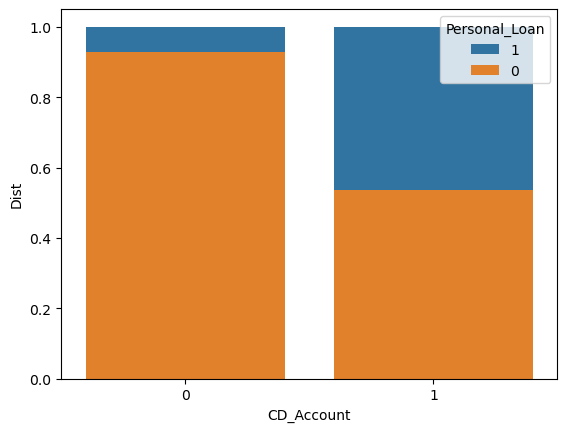

```python
distribution = pd.crosstab(loan_copy_1.CD_Account, loan_copy_1.Personal_Loan, normalize='index')

# plot the cumsum, with reverse hue order
sns.barplot(data=distribution.cumsum(axis=1).stack().reset_index(name='Dist'),
            x='CD_Account', y='Dist', hue='Personal_Loan',
            hue_order = distribution.columns[::-1],   # reverse hue order so that the taller bars got plotted first
            dodge=False)
```

#### Personal Loan Vs Online

- From the metric we can see that there is not much difference betwen customers who use Online Services or not on Personal Loans taken.

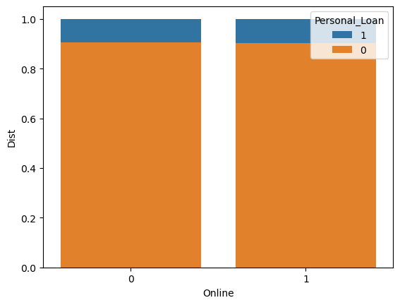

```python
distribution = pd.crosstab(loan_copy_1.Online, loan_copy_1.Personal_Loan, normalize='index')

# plot the cumsum, with reverse hue order
sns.barplot(data=distribution.cumsum(axis=1).stack().reset_index(name='Dist'),
            x='Online', y='Dist', hue='Personal_Loan',
            hue_order = distribution.columns[::-1],   # reverse hue order so that the taller bars got plotted first
            dodge=False)
```

#### Personal Loan Vs ZIPCode

- We can see that certain zipcodes have higher number of customers with personal loans.
- This data will be beneficial for the bank to identify prospective customers with certain zip codes.

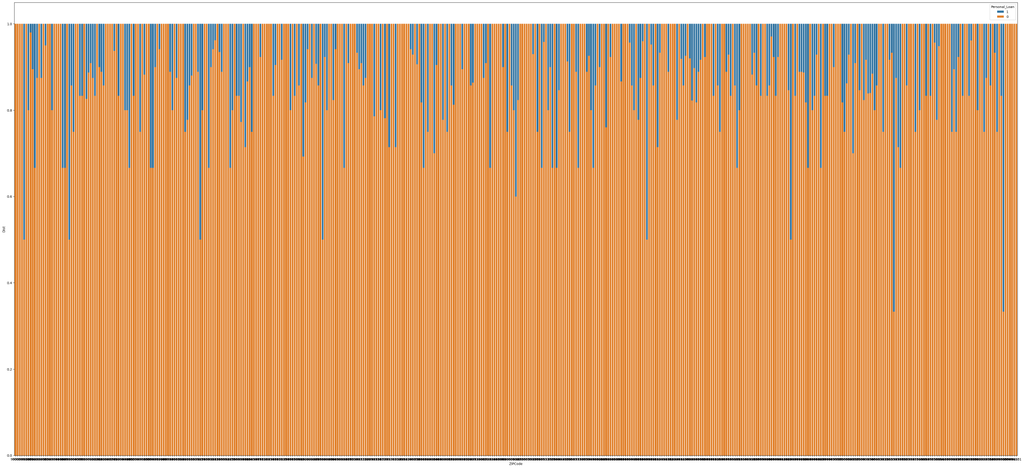

```python
distribution = pd.crosstab(loan_copy_1.ZIPCode, loan_copy_1.Personal_Loan, normalize='index')

# plot the cumsum, with reverse hue order
plt.figure(figsize=(55,25))
sns.barplot(data=distribution.cumsum(axis=1).stack().reset_index(name='Dist'),
            x='ZIPCode', y='Dist', hue='Personal_Loan',
            hue_order = distribution.columns[::-1],   # reverse hue order so that the taller bars got plotted first
            dodge=False)
```

#### Personal Loan Vs Education

- We can see that better Education have higher number of customers with personal loans.
- This data will be beneficial for the bank to identify prospective customers with Education information.

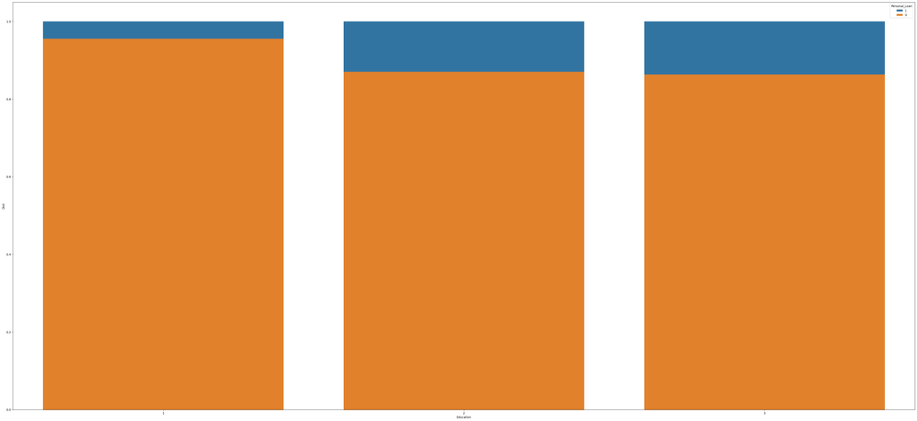

```python
distribution = pd.crosstab(loan_copy_1.Education, loan_copy_1.Personal_Loan, normalize='index')

# plot the cumsum, with reverse hue order
plt.figure(figsize=(55,25))
sns.barplot(data=distribution.cumsum(axis=1).stack().reset_index(name='Dist'),
            x='Education', y='Dist', hue='Personal_Loan',
            hue_order = distribution.columns[::-1],   # reverse hue order so that the taller bars got plotted first
            dodge=False)
```

#### Observations

We can see that the following factors contribute to the the personal loan taken up by a customer:

- Education : Higher qualified members have a personal loan
- Zip Code : Zip codes gives the details that there are zip codes with customers taking loan
- CD Account : Customers with a CD account also reveals that they have taken loans compared to customer that don't have a CD account.
- Family : More members in a family are the ones that have taken personal loan.

```python
data = loan_copy_1.copy()
```

```python
data.info()
```

```
<class 'pandas.core.frame.DataFrame'>
RangeIndex: 5000 entries, 0 to 4999
Data columns (total 14 columns):
 #   Column              Non-Null Count  Dtype
---  ------              --------------  -----
 0   ID                  5000 non-null   int64
 1   Age                 5000 non-null   int64
 2   Experience          5000 non-null   int64
 3   Income              5000 non-null   int64
 4   ZIPCode             5000 non-null   category
 5   Family              5000 non-null   int64
 6   CCAvg               5000 non-null   float64
 7   Education           5000 non-null   category
 8   Mortgage            5000 non-null   int64
 9   Personal_Loan       5000 non-null   category
 10  Securities_Account  5000 non-null   category
 11  CD_Account          5000 non-null   category
 12  Online              5000 non-null   category
 13  CreditCard          5000 non-null   category
dtypes: category(7), float64(1), int64(6)
memory usage: 333.2 KB
```

```python
loan_copy_1.head()
```

|  | ID | Age | Experience | Income | ZIPCode | Family | CCAvg | Education | Mortgage | Personal_Loan | Securities_Account | CD_Account | Online | CreditCard |
| --- | --- | --- | --- | --- | --- | --- | --- | --- | --- | --- | --- | --- | --- | --- |
| 0 | 1 | 25 | 1 | 49 | 91107 | 4 | 1.6 | 1 | 0 | 0 | 1 | 0 | 0 | 0 |
| 1 | 2 | 45 | 19 | 34 | 90089 | 3 | 1.5 | 1 | 0 | 0 | 1 | 0 | 0 | 0 |
| 2 | 3 | 39 | 15 | 11 | 94720 | 1 | 1.0 | 1 | 0 | 0 | 0 | 0 | 0 | 0 |
| 3 | 4 | 35 | 9 | 100 | 94112 | 1 | 2.7 | 2 | 0 | 0 | 0 | 0 | 0 | 0 |
| 4 | 5 | 35 | 8 | 45 | 91330 | 4 | 1.0 | 2 | 0 | 0 | 0 | 0 | 0 | 1 |

## Data Prep before Modeling

```python
# Defining independent and dependent variable

X = data.drop(["Personal_Loan", "ID"], axis=1)
Y = data["Personal_Loan"]
```

```python
# Defining one-hot-columns for setting up dummy columns

# oneHotCols=["Education","ZIPCode"]

oneHotCols=["Education"]
```

```python
# Applying dummies on ZIPCode and Education

X = pd.get_dummies(X, columns=oneHotCols, drop_first=True)
```

```python
data.info()
```

```
<class 'pandas.core.frame.DataFrame'>
RangeIndex: 5000 entries, 0 to 4999
Data columns (total 14 columns):
 #   Column              Non-Null Count  Dtype
---  ------              --------------  -----
 0   ID                  5000 non-null   int64
 1   Age                 5000 non-null   int64
 2   Experience          5000 non-null   int64
 3   Income              5000 non-null   int64
 4   ZIPCode             5000 non-null   category
 5   Family              5000 non-null   int64
 6   CCAvg               5000 non-null   float64
 7   Education           5000 non-null   category
 8   Mortgage            5000 non-null   int64
 9   Personal_Loan       5000 non-null   category
 10  Securities_Account  5000 non-null   category
 11  CD_Account          5000 non-null   category
 12  Online              5000 non-null   category
 13  CreditCard          5000 non-null   category
dtypes: category(7), float64(1), int64(6)
memory usage: 333.2 KB
```

```python
X.info()
```

```
<class 'pandas.core.frame.DataFrame'>
RangeIndex: 5000 entries, 0 to 4999
Data columns (total 13 columns):
 #   Column              Non-Null Count  Dtype
---  ------              --------------  -----
 0   Age                 5000 non-null   int64
 1   Experience          5000 non-null   int64
 2   Income              5000 non-null   int64
 3   ZIPCode             5000 non-null   category
 4   Family              5000 non-null   int64
 5   CCAvg               5000 non-null   float64
 6   Mortgage            5000 non-null   int64
 7   Securities_Account  5000 non-null   category
 8   CD_Account          5000 non-null   category
 9   Online              5000 non-null   category
 10  CreditCard          5000 non-null   category
 11  Education_2         5000 non-null   uint8
 12  Education_3         5000 non-null   uint8
dtypes: category(5), float64(1), int64(5), uint8(2)
memory usage: 293.9 KB
```

```python
Y.info()
```

```
<class 'pandas.core.series.Series'>
RangeIndex: 5000 entries, 0 to 4999
Series name: Personal_Loan
Non-Null Count  Dtype
--------------  -----
5000 non-null   category
dtypes: category(1)
memory usage: 5.1 KB
```

```python
# Complete the code to split data in train and test sets

X_train, X_test, y_train, y_test = train_test_split(X, Y, test_size=0.30, random_state=1)
```

```python
print("Shape of Training set : ", X_train.shape)     # Complete the code to get the shape of train data
print("Shape of test set : ", X_test.shape)           # Complete the code to get the shape of test data
print("Percentage of classes in training set:")
print(y_train.value_counts(normalize=True))              # Complete the code to get the value counts of y train data
print("Percentage of classes in test set:")
print(y_test.value_counts(normalize=True))           # Complete the code to get the value counts of y test data
```

```
Shape of Training set :  (3500, 13)
Shape of test set :  (1500, 13)
Percentage of classes in training set:
0    0.905429
1    0.094571
Name: Personal_Loan, dtype: float64
Percentage of classes in test set:
0    0.900667
1    0.099333
Name: Personal_Loan, dtype: float64
```

## Model Building

### Model Evaluation Criterion

### Model Building

```python
# defining a function to compute different metrics to check performance of a classification model built using sklearn
def model_performance_classification_sklearn(model, predictors, target):
    """
    Function to compute different metrics to check classification model performance

    model: classifier
    predictors: independent variables
    target: dependent variable
    """

    # predicting using the independent variables
    pred = model.predict(predictors)

    acc = accuracy_score(target, pred)  # to compute Accuracy
    recall = recall_score(target, pred)  # to compute Recall
    precision = precision_score(target, pred)  # to compute Precision
    f1 = f1_score(target, pred)  # to compute F1-score

    # creating a dataframe of metrics
    df_perf = pd.DataFrame(
        {"Accuracy": acc, "Recall": recall, "Precision": precision, "F1": f1,},
        index=[0],
    )

    return df_perf
```

```python
def confusion_matrix_sklearn(model, predictors, target):
    """
    To plot the confusion_matrix with percentages

    model: classifier
    predictors: independent variables
    target: dependent variable
    """
    y_pred = model.predict(predictors)
    cm = confusion_matrix(target, y_pred)
    labels = np.asarray(
        [
            ["{0:0.0f}".format(item) + "\n{0:.2%}".format(item / cm.flatten().sum())]
            for item in cm.flatten()
        ]
    ).reshape(2, 2)

    plt.figure(figsize=(6, 4))
    sns.heatmap(cm, annot=labels, fmt="")
    plt.ylabel("True label")
    plt.xlabel("Predicted label")
```

#### Build Decision Tree Model

```python
# Initialize the Decision Tree Classifier
dTreeModel = DecisionTreeClassifier(criterion="gini", random_state=1)
dTreeModel.fit(X_train, y_train)
```

```
DecisionTreeClassifier(random_state=1)
```

```python
print("Accuracy on training set : ",dTreeModel.score(X_train, y_train))
print("Accuracy on test set : ",dTreeModel.score(X_test, y_test))
```

```
Accuracy on training set :  1.0
Accuracy on test set :  0.986
```

### ITERATION (1)

(1) Now, post building the model, we will iterate the model and test the performance of the training and test data.

(2) We will prune the model, pre anmd post bulding the decicion tree

(3) Post this step, we will then compare the model outputs.

#### ITERATION (1) - Checking model performance on training data

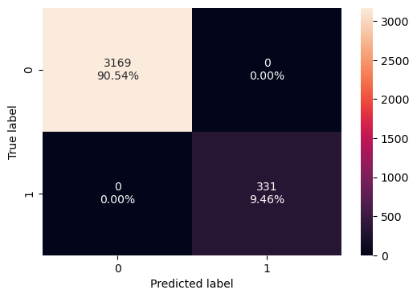

```python
# Confusion Matrix (from the training Model)

confusion_matrix_sklearn(dTreeModel, X_train, y_train)
```

```python
decision_tree_perf_train = model_performance_classification_sklearn(dTreeModel, X_train, y_train)
decision_tree_perf_train
```

|  | Accuracy | Recall | Precision | F1 |
| --- | --- | --- | --- | --- |
| 0 | 1.0 | 1.0 | 1.0 | 1.0 |

#### ITERATION (1) - Visualizing the Decision Tree (Training Data)

```python
feature_names = list(X_train.columns)
print(feature_names)
```

```
['Age', 'Experience', 'Income', 'ZIPCode', 'Family', 'CCAvg', 'Mortgage', 'Securities_Account', 'CD_Account', 'Online', 'CreditCard', 'Education_2', 'Education_3']
```

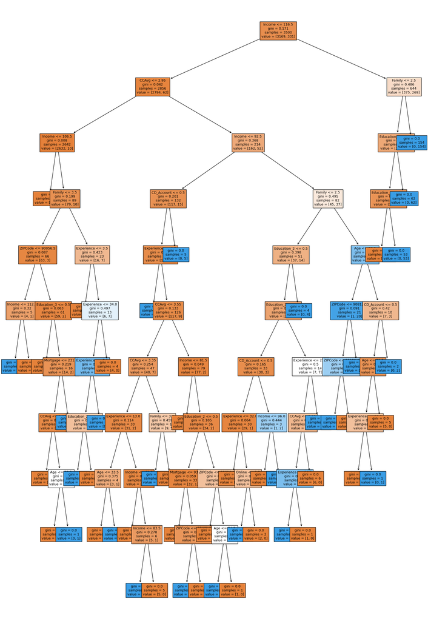

```python
plt.figure(figsize=(20, 30))
out = tree.plot_tree(
    dTreeModel,
    feature_names=feature_names,
    filled=True,
    fontsize=9,
    node_ids=False,
    class_names=None,
)
# below code will add arrows to the decision tree split if they are missing
for o in out:
    arrow = o.arrow_patch
    if arrow is not None:
        arrow.set_edgecolor("black")
        arrow.set_linewidth(1)
plt.show()
```

```python
# Text report showing the rules of a decision tree -

print(tree.export_text(dTreeModel, feature_names=feature_names, show_weights=True))
```

```
|--- Income <= 116.50
|   |--- CCAvg <= 2.95
|   |   |--- Income <= 106.50
|   |   |   |--- weights: [2553.00, 0.00] class: 0
|   |   |--- Income >  106.50
|   |   |   |--- Family <= 3.50
|   |   |   |   |--- ZIPCode <= 90056.50
|   |   |   |   |   |--- Income <= 112.50
|   |   |   |   |   |   |--- weights: [0.00, 1.00] class: 1
|   |   |   |   |   |--- Income >  112.50
|   |   |   |   |   |   |--- weights: [4.00, 0.00] class: 0
|   |   |   |   |--- ZIPCode >  90056.50
|   |   |   |   |   |--- Education_3 <= 0.50
|   |   |   |   |   |   |--- weights: [45.00, 0.00] class: 0
|   |   |   |   |   |--- Education_3 >  0.50
|   |   |   |   |   |   |--- Mortgage <= 231.00
|   |   |   |   |   |   |   |--- CCAvg <= 1.95
|   |   |   |   |   |   |   |   |--- weights: [13.00, 0.00] class: 0
|   |   |   |   |   |   |   |--- CCAvg >  1.95
|   |   |   |   |   |   |   |   |--- Age <= 39.00
|   |   |   |   |   |   |   |   |   |--- weights: [1.00, 0.00] class: 0
|   |   |   |   |   |   |   |   |--- Age >  39.00
|   |   |   |   |   |   |   |   |   |--- weights: [0.00, 1.00] class: 1
|   |   |   |   |   |   |--- Mortgage >  231.00
|   |   |   |   |   |   |   |--- weights: [0.00, 1.00] class: 1
|   |   |   |--- Family >  3.50
|   |   |   |   |--- Experience <= 3.50
|   |   |   |   |   |--- weights: [10.00, 0.00] class: 0
|   |   |   |   |--- Experience >  3.50
|   |   |   |   |   |--- Experience <= 34.00
|   |   |   |   |   |   |--- Experience <= 7.00
|   |   |   |   |   |   |   |--- Education_2 <= 0.50
|   |   |   |   |   |   |   |   |--- weights: [0.00, 1.00] class: 1
|   |   |   |   |   |   |   |--- Education_2 >  0.50
|   |   |   |   |   |   |   |   |--- weights: [2.00, 0.00] class: 0
|   |   |   |   |   |   |--- Experience >  7.00
|   |   |   |   |   |   |   |--- weights: [0.00, 6.00] class: 1
|   |   |   |   |   |--- Experience >  34.00
|   |   |   |   |   |   |--- weights: [4.00, 0.00] class: 0
|   |--- CCAvg >  2.95
```

[output cut: 93 more lines]

```
|   |   |   |   |   |   |--- Age >  59.50
|   |   |   |   |   |   |   |--- weights: [5.00, 0.00] class: 0
|   |   |   |   |   |--- CD_Account >  0.50
|   |   |   |   |   |   |--- weights: [0.00, 2.00] class: 1
|--- Income >  116.50
|   |--- Family <= 2.50
|   |   |--- Education_3 <= 0.50
|   |   |   |--- Education_2 <= 0.50
|   |   |   |   |--- weights: [375.00, 0.00] class: 0
|   |   |   |--- Education_2 >  0.50
|   |   |   |   |--- weights: [0.00, 53.00] class: 1
|   |   |--- Education_3 >  0.50
|   |   |   |--- weights: [0.00, 62.00] class: 1
|   |--- Family >  2.50
|   |   |--- weights: [0.00, 154.00] class: 1
```

```python
# importance of features in the tree building ( The importance of a feature is computed as the
# (normalized) total reduction of the criterion brought by that feature. It is also known as the Gini importance )

print(
    pd.DataFrame(
        dTreeModel.feature_importances_, columns=["Imp"], index=X_train.columns
    ).sort_values(by="Imp", ascending=False)
)
```

```
                         Imp
Income              0.306133
Family              0.257587
Education_2         0.165636
Education_3         0.144822
CCAvg               0.048134
Experience          0.027822
CD_Account          0.021361
Age                 0.016154
ZIPCode             0.007025
Mortgage            0.003101
Online              0.002224
Securities_Account  0.000000
CreditCard          0.000000
```

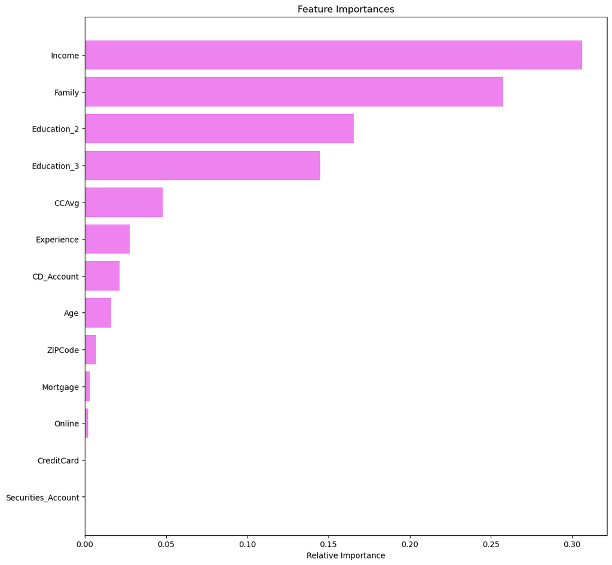

```python
importances = dTreeModel.feature_importances_
indices = np.argsort(importances)

plt.figure(figsize=(12,12))
plt.title("Feature Importances")
plt.barh(range(len(indices)), importances[indices], color="violet", align="center")
plt.yticks(range(len(indices)), [feature_names[i] for i in indices])
plt.xlabel("Relative Importance")
plt.show()
```

#### Observations

- From the above observations we can see that income is the most important feature that drives the personal loan decision followed by family size and education.

#### ITERATION (1) - Checking model performance on test data

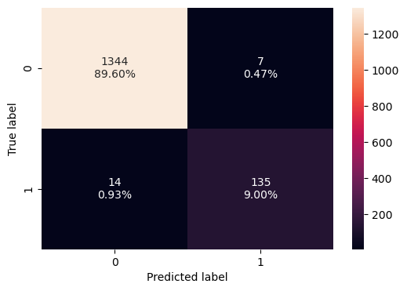

```python
confusion_matrix_sklearn(dTreeModel, X_test, y_test)
```

```python
# Complete the code to get the model formance on test data

decision_tree_perf_test = model_performance_classification_sklearn(dTreeModel, X_test, y_test)
decision_tree_perf_test
```

|  | Accuracy | Recall | Precision | F1 |
| --- | --- | --- | --- | --- |
| 0 | 0.986 | 0.90604 | 0.950704 | 0.927835 |

#### OBSERVATIONS 1

##### Comparing the performance of training and test data on the first model with no model tuning

###### Performance Training

- Accuracy : 1.0
- Recall : 1.0
- Precision: 1.0
- F1 Score : 1.0

###### Performance Testing

- Accuracy : 0.986
- Recall : 0.90604
- Precision: 0.950704
- F1 Score : 0.927835

### ITERATION 2

### Improving Model Performance by Pre-Pruning

#### ITERATION (2) - Pre Pruning : Setting MAX DEPTH to 6

```python
# Pre-pruning the ddecision tree and checking the performance of the model
# Keeping the max depth to 6


dTreeModel1 = DecisionTreeClassifier(criterion = 'gini',
                                max_depth=6,
                                random_state=1)

dTreeModel1.fit(X_train, y_train)
```

```
DecisionTreeClassifier(max_depth=6, random_state=1)
```

#### ITERATION (2) - Checking performance on training data

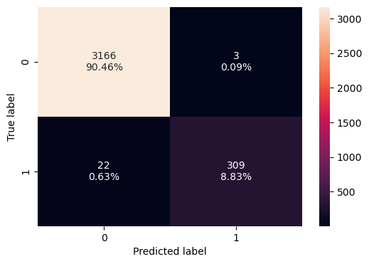

```python
confusion_matrix_sklearn(dTreeModel1, X_train, y_train)
```

```python
# Accuracy, Recall and Precision on training set

decision_tree_perf_pre_train = model_performance_classification_sklearn(dTreeModel1, X_train, y_train)
decision_tree_perf_pre_train
```

|  | Accuracy | Recall | Precision | F1 |
| --- | --- | --- | --- | --- |
| 0 | 0.992857 | 0.933535 | 0.990385 | 0.96112 |